# Kaggle with R

2021-08-08T21:00:00+09:00

## XGBoost 개요

- 논문 제목 - [XGBoost: A Scalable Tree Boosting System](https://arxiv.org/abs/1603.02754)
- 논문 게재일: Wed, 9 Mar 2016 01:11:51 UTC (592 KB)
- 논문 저자: Tianqi Chen, Carlos Guestrin
- 논문 소개 > Tree boosting is a highly effective and widely used machine learning method. In this paper, we describe a scalable end-to-end tree boosting system called XGBoost, which is used widely by data scientists to achieve state-of-the-art results on many machine learning challenges. We propose a novel sparsity-aware algorithm for sparse data and weighted quantile sketch for approximate tree learning. More importantly, we provide insights on cache access patterns, data compression and sharding to build a scalable tree boosting system. By combining these insights, XGBoost scales beyond billions of examples using far fewer resources than existing systems.
- 효과적인 머신러닝 방법
  - 확장가능한 머신러닝 모형
  - A novel sparsity-aware algorithm
  - Cache access patterns, Data compression and Sharding
    - 위 조합을 통해 기존 시스템보다 훨씬 더 적은 리소스를 투입해도 좋은 성과를 낼 수 있도록 구현함.

## 논문 주요 내용 요약

- `XGboost`는 `GBM`에서 나온 출발한 알고리즘
- 논문에 있는 주요 내용을 요약한다.

### (1) 과적합 규제

- 표준 GBM의 경우 과적합 규제 기능이 없으나 XGBoost는 자체에 과적합 규제 기능으로 과적합에 좀 더 강한 내구성 가짐.
  - The additional regularization term helps to smooth the final learnt weights to avoid over-fitting. Intuitively, the regularized objective will tend to select a model employing simple and predictive functions.

### (2) shrinkage and Column Subsampling

- 두 기법 모두 과적합 방지용으로 사용됨
  - shrinkage: reduces the influence of each individual tree and leaves space for future trees to improve the model.
  - Column Subsampling: 랜덤포레스트에 있는 기법, 변수가 많을 때, 변수의 개수를 지정하면 랜덤하게 변수가 투입됨
    - 병렬처리에 적합함

## 실습 코드

- 우선 패키지부터 설치한다.

```r
library(tidyverse)
library(xgboost)
```

### (1) 데이터 불러오기

- 이제 `titanic` 데이터를 불러오자
  - 처음 `kaggle` 대회에 참여하는 사람들은 우선 `Join Competiton` 버튼을 클릭한다.
    - 참고: [Google Colab with Kaggle - Beginner](https://chloevan.github.io/settings/kaggle_with_colab_beginner/)
- 소스코드로 확인해본다.

```r
library(readr)
train <- read_csv("data/train.csv")
test <- read_csv("data/test.csv")

dim(train); dim(test)
```

```
## [1] 891  12
```

```
## [1] 418  11
```

- 데이터가 정상적으로 불러와진 것을 확인할 수 있다.
- 간단한 시각화, 데이터 가공 후, 모형 생성 및 제출까지 진행하도록 해본다.

#### 변수 설명

- survival : 생존유무, target 값. (0 = 사망, 1 = 생존)
- pclass : 티켓 클래스. (1 = 1st, 2 = 2nd, 3 = 3rd)
- sex : 성별
- Age : 나이(세)
- sibsp : 함께 탑승한 형제자매, 배우자 수 총합
- parch : 함께 탑승한 부모, 자녀 수 총합
- ticket : 티켓 넘버
- fare : 탑승 요금
- cabin : 객실 넘버
- embarked : 탑승 항구

### (3) 데이터 전처리 (중복값 & 결측치)

- 데이터를 불러온 뒤에는 항상 중복값 및 결측치를 확인한다.
- 먼저 중복값을 확인하자.
  - sample code

```r
temp <- data.frame(a = c(1, 1, 2, 3),
                   b = c("a", "a", "b", "c"))

sum(duplicated(temp))
```

```
## [1] 1
```

- 이와 같은 방식으로 계산할 수 있다.
- 중복값을 제거할 때는 `dplyr` 패키지 내에 있는 `distinct()` 사용한다.

```r
dplyr::distinct(temp)
```

```
##   a b
## 1 1 a
## 2 2 b
## 3 3 c
```

- 이제 본 데이터에 적용한다.

```r
train <- dplyr::distinct(train); dim(train)
```

```
## [1] 891  12
```

```r
test <- dplyr::distinct(test); dim(test)
```

```
## [1] 418  11
```

- train 데이터의 결측치의 개수를 확인해본다.

```r
colSums(is.na(train))
```

```
## PassengerId    Survived      Pclass        Name         Sex         Age
##           0           0           0           0           0         177
##       SibSp       Parch      Ticket        Fare       Cabin    Embarked
##           0           0           0           0         687           2
```

- 훈련데이터에서 결측치가 있는 변수는 `Cabin`, `Age`, `Embarked`로 확인되었다.
- test 데이터의 결측치의 개수를 확인해본다.

```r
colSums(is.na(test))
```

```
## PassengerId      Pclass        Name         Sex         Age       SibSp
##           0           0           0           0          86           0
##       Parch      Ticket        Fare       Cabin    Embarked
##           0           0           1         327           0
```

- 테스트 데이터에서 결측치가 있는 변수는 `Cabin`, `Age`, `Fare`로 확인되었다.

```r
class(train$Age)
```

```
## [1] "numeric"
```

- 우선 히스토그램으로 데이터의 분포를 확인해보자.

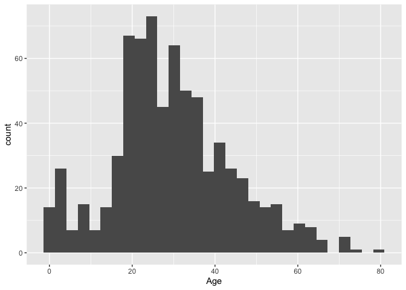

```r
library(ggplot2)
ggplot(train, aes(x = Age)) +
  geom_histogram()
```

- 숫자를 재 범주화 할 필요가 있다.

### (5) 도메인 지식의 필요성

- `Age`를 현대적 관점 및 국내 관점에서 바라봐서는 안된다.
  - 1910년도에는 10대부터 일을 시작했다는 것을 잊지 말자.
  - 또한 그들은 위험이 닥쳐도 어느정도 스스로 해결할 수 있는 나이였다는 것을 기억하자.
- 필자가 나눈 연령대는 다음과 같다.
  - missing values: non-values
  - 0-13: children
  - 14-18: teenagers
  - 19-64: adults
  - over 65: senior
- 이제 코딩을 진행한다.
  - `cut()` 함수를 활용한다.

```r
age_cut <- function(x) {

  data <- x["Age"]
  # 지역변수 할당
  age_labels <- c("children", "teenagers", "adults", "senior")

  if(sum(is.na(x)) > 0) {
    # 결측치가 있는 경우 추가
    print("결측치가 존재합니다.")
    int2cat <- cut(as.integer(data$Age),
                 breaks=c(0, 13, 18, 64,
                          max(data$Age, na.rm = TRUE)),
                 labels=age_labels)
    int2cat <- addNA(int2cat)
    cat("The levels are:", levels(int2cat))
  } else {
    print("결측치가 존재 하지 않습니다.")
    int2cat <- cut(as.integer(data$Age),
                 breaks=c(0, 13, 18, 64,
                          max(data$Age, na.rm = TRUE)),
                 labels=age_labels)
    cat("The levels are:", levels(int2cat))
  }

  return(int2cat)
}

# 이제 변환을 시도한다.
train$Age <- age_cut(train)
```

```
## [1] "결측치가 존재합니다."
## The levels are: children teenagers adults senior NA
```

```r
test$Age <- age_cut(test)
```

```
## [1] "결측치가 존재합니다."
## The levels are: children teenagers adults senior NA
```

- 동일 작업을 해야했기 때문에 함수를 만들었다.
  - `breaks`를 보정하면 조금 더 깔끔한 함수가 나올 수 있을 것 같다.
  - 그러나, 이쯤에서 정리하도록 한다.
- 이제 마지막으로 `summary()` 함수를 통해 최종적으로 데이터를 확인한다.
- 이 외에도 더 많은 변수들을 가공할 수 있지만, 마찬가지로 독자들에게 맡기도록 하겠다.
  - 주어진 변수들을 활용하여 `single`, `small family`, `large family`으로 구분하는 도출 변수를 만들어 보자.
    - 참고: [Exploring the Titanic Dataset](https://rstudio-pubs-static.s3.amazonaws.com/202517_d1c1e3e9101d49b1a0135a422a9b3748.html#do-families-sink-or-swim-together)

```r
summary(train)
```

```
##   PassengerId       Survived          Pclass          Name
##  Min.   :  1.0   Min.   :0.0000   Min.   :1.000   Length:891
##  1st Qu.:223.5   1st Qu.:0.0000   1st Qu.:2.000   Class :character
##  Median :446.0   Median :0.0000   Median :3.000   Mode  :character
##  Mean   :446.0   Mean   :0.3838   Mean   :2.309
##  3rd Qu.:668.5   3rd Qu.:1.0000   3rd Qu.:3.000
##  Max.   :891.0   Max.   :1.0000   Max.   :3.000
##      Sex                   Age          SibSp           Parch
##  Length:891         children : 64   Min.   :0.000   Min.   :0.0000
##  Class :character   teenagers: 68   1st Qu.:0.000   1st Qu.:0.0000
##  Mode  :character   adults   :564   Median :0.000   Median :0.0000
##                     senior   : 11   Mean   :0.523   Mean   :0.3816
##                     NA       :184   3rd Qu.:1.000   3rd Qu.:0.0000
##                                     Max.   :8.000   Max.   :6.0000
##     Ticket               Fare           Cabin             Embarked
##  Length:891         Min.   :  0.00   Length:891         Length:891
##  Class :character   1st Qu.:  7.91   Class :character   Class :character
##  Mode  :character   Median : 14.45   Mode  :character   Mode  :character
##                     Mean   : 32.20
##                     3rd Qu.: 31.00
##                     Max.   :512.33
```

- 이 때의 `NA`는 재 가공된 `NA`이다.

### (6) 시각화 예제

- 시각화의 기본적인 원리는 `타겟변수`와의 관계이다.
- 머신러닝의 주요 내용이 결국 최적의 `feature` 찾기와 연관이 크기 때문이다.
- 시각화 및 기초 통계량 검증을 통해 의미 있는 데이터를 파악하도록 한다.
  - 그 외, 다양한 예제는 독자들에게 맡기겠다.
- 간단하게 예시만 확인해본다.

```r
prop.table(table(train$Sex,train$Survived),1)
```

```
##
##                  0         1
##   female 0.2579618 0.7420382
##   male   0.8110919 0.1889081
```

- 교차분석을 통해서 확인할 수 있는 것은 여성들이 살 확률이 더 높았다는 것이다.
  - `Lady First`

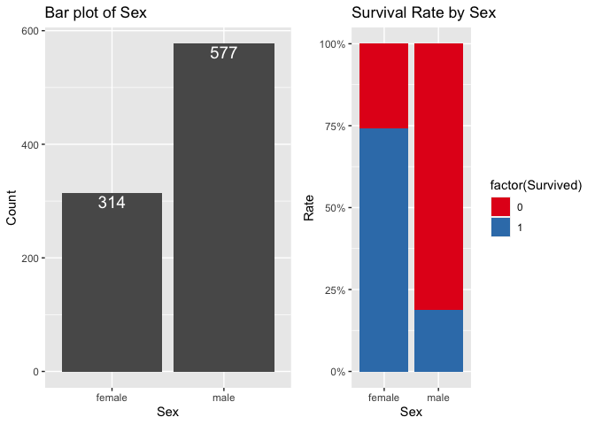

```r
library(gridExtra)
library(ggplot2)
library(dplyr)

# 성별 막대그래프
p1 <- train %>%
  group_by(Sex) %>%
  summarise(N = n(), .groups = 'drop') %>%
  ggplot(aes(Sex, N)) +
  geom_col() +
  geom_text(aes(label = N), size = 5, vjust = 1.2, color = "#FFFFFF") +
  ggtitle("Bar plot of Sex") +
  labs(x = "Sex", y = "Count")

# 성별에 따른 Survived 막대그래프
p2 <- train%>%
  dplyr::filter(!is.na(Survived)) %>%
  ggplot(aes(factor(Sex), fill = factor(Survived))) +
  geom_bar(position = "fill") +
  scale_y_continuous(labels = scales::percent) +
  scale_fill_brewer(palette = "Set1") +
  ggtitle("Survival Rate by Sex") +
  labs(x = "Sex", y = "Rate")

grid.arrange(p1, p2, ncol=2)
```

- 교차분석을 통해 확인된 사항을 시각적으로 한번 더 증명하면 된다.
- Note: `summarize` 함수가 `dplyr version 1.0.0`과 함께 업데이트 되었다.
  - 현재 `.groups`를 실험하고 있으며, 만약 기존과 같이 사용하고 싶다면, 아래와 같이 설정한다. [참조: dplyr 1.0.0: last minute additions](https://www.tidyverse.org/blog/2020/05/dplyr-1-0-0-last-minute-additions/)

  ```r
  options(dplyr.summarise.inform = FALSE)
  ```

- 시각화는 위와 같은 방식으로 하는 것이 적정하다.
- 통계적 분석 + 시각적 분석 동시에 수행할 때, 보다 데이터가 잘 보인다.

### (7) 변수 선택 및 변환

- 변수 선택 시, 기본은 ID와 이름은 제거 한다.
- 또한, 모든 변수가 수치형 또는 `factor`로 변환 한다.

```r
dplyr::glimpse(train)
```

```
## Rows: 891
## Columns: 12
## $ PassengerId <dbl> 1, 2, 3, 4, 5, 6, 7, 8, 9, 10, 11, 12, 13, 14, 15, 16, 17,…
## $ Survived    <dbl> 0, 1, 1, 1, 0, 0, 0, 0, 1, 1, 1, 1, 0, 0, 0, 1, 0, 1, 0, 1…
## $ Pclass      <dbl> 3, 1, 3, 1, 3, 3, 1, 3, 3, 2, 3, 1, 3, 3, 3, 2, 3, 2, 3, 3…
## $ Name        <chr> "Braund, Mr. Owen Harris", "Cumings, Mrs. John Bradley (Fl…
## $ Sex         <chr> "male", "female", "female", "female", "male", "male", "mal…
## $ Age         <fct> adults, adults, adults, adults, adults, NA, adults, childr…
## $ SibSp       <dbl> 1, 1, 0, 1, 0, 0, 0, 3, 0, 1, 1, 0, 0, 1, 0, 0, 4, 0, 1, 0…
## $ Parch       <dbl> 0, 0, 0, 0, 0, 0, 0, 1, 2, 0, 1, 0, 0, 5, 0, 0, 1, 0, 0, 0…
## $ Ticket      <chr> "A/5 21171", "PC 17599", "STON/O2. 3101282", "113803", "37…
## $ Fare        <dbl> 7.2500, 71.2833, 7.9250, 53.1000, 8.0500, 8.4583, 51.8625,…
## $ Cabin       <chr> NA, "C85", NA, "C123", NA, NA, "E46", NA, NA, NA, "G6", "C…
## $ Embarked    <chr> "S", "C", "S", "S", "S", "Q", "S", "S", "S", "C", "S", "S"…
```

- 변수 선택을 하도록 하는데, 여기에서는 `PassengerId`, `Name`, `Ticket`은 제거한다.
  - 값을 출력해보면 알겠지만, `level`의 수가 많다.
- 또한 `Cabin`의 결측치가 많기 때문에 또한 제거한다.
  - `train` & `test` 데이터 모두에 적용한다.
- 이제 티겟값을 의미하는 `Fare`를 제외하고 모든 변수를 범주화를 진행한다.

```r
feature_df <- function(train, test) {

  # 데이터셋 합치기
  test$Survived <- NA
  combi_df <- rbind(train, test)

  del_vars <- c("PassengerId", "Name", "Ticket", "Cabin")
  fct_vars <- c("Survived", "Pclass", "Sex", "SibSp", "Parch", "Embarked")

  # which(is.na(combi_df)) = 1044
  combi_df$Fare[1044] <- median(combi_df$Fare, na.rm=TRUE)

  combi_df <- combi_df %>%
    select(-del_vars) %>%
     mutate_at(.vars = fct_vars, .funs = as.factor)

  combi_df$Embarked <- addNA(combi_df$Embarked)
  return(combi_df)
}

master <- feature_df(train, test)
summary(master)
```

```
##  Survived   Pclass      Sex             Age      SibSp       Parch
##  0   :549   1:323   female:466   children : 87   0:891   0      :1002
##  1   :342   2:277   male  :843   teenagers: 97   1:319   1      : 170
##  NA's:418   3:709                adults   :837   2: 42   2      : 113
##                                  senior   : 13   3: 20   3      :   8
##                                  NA       :275   4: 22   4      :   6
##                                                  5:  6   5      :   6
##                                                  8:  9   (Other):   4
##       Fare         Embarked
##  Min.   :  0.000   C :270
##  1st Qu.:  7.896   Q :123
##  Median : 14.454   S :914
##  Mean   : 33.281   NA:  2
##  3rd Qu.: 31.275
##  Max.   :512.329
##
```

### (8) 데이터셋 준비

- 머신러닝 수행 전, xgboost에 맞도록 `matrix`로 변환해줘야 한다. - 우선 `Survived` 값 기준으로 분리 한다.

```r
train <- master %>% filter(is.na(Survived)==FALSE)
test <- master %>% filter(is.na(Survived)==TRUE)
```

- 다음 `xgboost` 모형에 적합하도록 데이터를 변형한다.
  - `data.frame`에서 `DMatrix` 계열로 변경해줘야 한다.
  - 또한, `label`을 지정해줘야 하는데, `label` 값을 `0`부터 표시해줘야 한다.
- 자세한 설명은 공식 메뉴얼을 참고한다.
  - [Understand your dataset with XGBoost](https://xgboost.readthedocs.io/en/latest/R-package/discoverYourData.html)

```r
train_label <- as.numeric(train$Survived)-1
test_label <- test$Survived

x_train<- model.matrix(~.-1, data = train[,-1]) %>% data.frame
x_test <- model.matrix(~.-1, data = test[,-1]) %>% data.frame

dtrain <- xgb.DMatrix(data = as.matrix(x_train),
                      label=train_label)
dtest <- xgb.DMatrix(data = as.matrix(x_test))
```

### (9) 모형 적합

- 이제 모형 적합을 진행한다.
  - 각 parameters에 대한 구체적인 설명은 공식 홈페이지를 참조 한다.
  - [XGBoost Parameters](https://xgboost.readthedocs.io/en/latest/parameter.html)

```r
set.seed(2020)
param <- list(objective   = "binary:logistic",
              eval_metric = "error",
              max_depth   = 5,
              eta         = 0.1,
              colsample_bytree = 1,
              min_child_weight = 1)

xgb <- xgb.train(params  = param,
              data    = dtrain,
              nrounds = 500,
              print_every_n = 100,
              verbose = 0)
```

### (10) 모형 예측

- 이제 모형을 예측하자.

```r
XGB_pred <- predict(xgb, dtest)
XGB_pred <- ifelse(XGB_pred >= 0.5, 1, 0)
```

- 해당 모형에 대한 중요 변수도를 확인해보자.

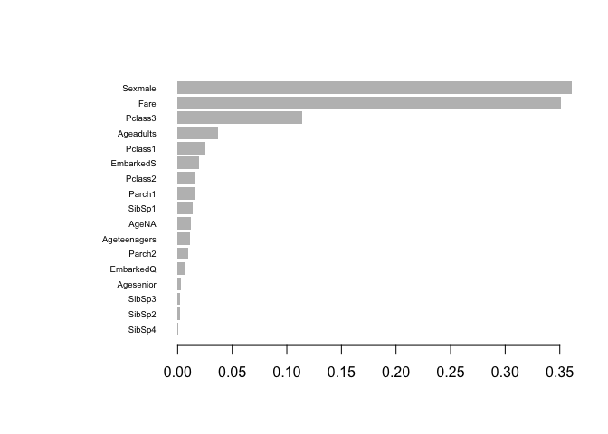

```r
xgb.importance(colnames(dtrain), model = xgb) %>%
  xgb.plot.importance(top_n = 30)
```